# DACSS785_Final_Project

Author

Kuan-Cheng Lee

## Research Question and Hypothesis

**How do the thematic content and emotional framing of YouTube comments about the “Suicide of Fat Cat” event relate to comment engagement (like count and reply count)?**

- **Null Hypothesis** (H₀):There is no significant linear relationship between the content themes of a comment (as represented by any topic probability from the LDA model) and its community engagement metrics ($\text{likeCount}$ and $\text{reply}$ count).
- **Alternative Hypothesis** (H₁):Comment content, specifically themes emphasizing emotional narratives and interpersonal relationships (e.g., Topic 3), will significantly predict higher community engagement ($\text{likeCount}$ and $\text{reply}$ count).

## Data Collection

To explore the concept of **“simping,”** I collected **YouTube comments** from six relevant videos for textual analysis. I utilized an **R scraping script** to extract approximately **8,000 comments** in total. Following a cleaning and filtering process, a dataset of around **7,000 practical comments** was retained for analysis.

I specifically focused on the case study known as the **“胖貓跳江事件” (Suicide of Fat Cat)**. This event, which occurred in **Mainland China**, provides a particularly rich and relevant dataset because it was a **well-documented news story officially reported by the Chinese court**. This official documentation makes it a **real and verifiable event**, distinguishing it from mere rumors or social media anecdotes. Furthermore, the use of **Chinese-language videos** as the reference source is critical, as the Chinese-speaking audience possesses **extensive background knowledge and cultural context** directly related to the local details of this incident.

1. **SIMP001 - 陪打遊戲賺百萬養女友慘遭分手！「胖貓事件」引爆中國性別戰爭？「撈女」滿街跑的背後原因？【TODAY 看世界】[(https://www.youtube.com/watch?v=o5TfkwlthWU&t=13s)](https://www.youtube.com/watch?v=o5TfkwlthWU&t=13s) 1952 comments from 11/04/2025**
2. **SIMP002 - 当胖猫遇到捞女，一个年轻人如何走上不归路？｜女权｜捞女｜胖猫｜王者荣耀｜男女平权｜日本｜梅大高速｜舆论控制｜王局拍案20240507 [(https://www.youtube.com/watch?v=39Gq_eOPuDY&t=1s)](https://www.youtube.com/watch?v=39Gq_eOPuDY&t=1s) 3731 comments from 11/04/2025**
3. **SIMP003 - 老梁：给“胖猫”多条选择 重庆“胖猫事件”不是性别大战 如何避免成为“胖猫”[(https://www.youtube.com/watch?v=mjcgg0wFpfE)](https://www.youtube.com/watch?v=mjcgg0wFpfE) 997 comments from 11/04/2025**
4. **SIMP004 - 小伙為愛跳江，拜金的女友，吸血的親姐，無良的商家，瘋狂的網民，誰才是加害者？為何警察認定女友無罪，反而是親姐違了法？一口氣看完胖貓事件始末！| Wayne調查[(https://www.youtube.com/watch?v=igs7GoIU4MU)](https://www.youtube.com/watch?v=igs7GoIU4MU) 615 comments from 11/04/2025**
5. **SIMP005 - 神級陪玩「胖貓」遭詐乾227萬亡 女友道歉｜20240506 ET午間新聞 [(https://www.youtube.com/watch?v=tAE83zZEcOY)](https://www.youtube.com/watch?v=tAE83zZEcOY) 402 comments from 11/04/2025**
6. **SIMP006 - 被撈女騙光50萬，遊戲宅男跳江自殺，轟動全網！撈女譚竹榨乾胖貓事件真相！『新闻最嘲点 姜光宇』2024.0508[(https://www.youtube.com/watch?v=YYngd2Yt3zk)](https://www.youtube.com/watch?v=YYngd2Yt3zk) 271 comments from 11/04/2025**

```r
library(plyr)
library(dplyr)
library(stringr)
library(tidytext)
library(readr)
library(purrr)
library(chromote)
library(stargazer)
library(readxl)
library(ggplot2)
library(tibble)
library(nnet)
library(corrplot)
library(tm)
library(wordcloud)
library(quanteda)
library(rvest)
library(jsonlite)
library("quanteda.textplots")
library(httr)
library(RColorBrewer)
library(RedditExtractoR)
library(httr2)
library(tidyr)
```

```r
data1 <- read.csv("Final_project_data/CN_SIMP001_comments.csv")
data2 <- read.csv("Final_project_data/CN_SIMP002_comments.csv")
data3 <- read.csv("Final_project_data/CN_SIMP003_comments.csv")
data4 <- read.csv("Final_project_data/CN_SIMP004_comments.csv")
data5 <- read.csv("Final_project_data/CN_SIMP005_comments.csv")
data6 <- read.csv("Final_project_data/CN_SIMP006_comments.csv")
```

The raw dataset, collected as several CSV files, initially contained detailed comment metadata. The original structure included columns such as: `videoId`, `commentId`, `parentId`, `author`, **`text`**, **`likeCount`**, `publishedAt`, `updatedAt`, `viewerRating`, `canRate`, and **`reply`**.

For data cleaning, all CSV files in the `Final_project_data` folder were systematically processed using the **R environment**. The initial step was to **streamline the dataset** by retaining only the essential variables for textual and engagement analysis: **`text`**, **`likeCount`**, and **`reply`**.

I utilized the R packages `dplyr` and `stringr` to focus on standardizing the **`text`** column. This involved a series of cleaning operations: **normalization of whitespace** (removing line breaks, tabs, and extra spaces, and trimming leading/trailing whitespace) and **character filtering**. Crucially, I removed non-essential symbols and unusual characters while **meticulously preserving all Chinese characters** to ensure the comments remained culturally authentic and meaningful for subsequent analysis.

Finally, each cleaned and standardized dataset was saved as a new CSV file, appended with the suffix `_cleaned`. **UTF-8 encoding** was explicitly used to guarantee the accurate representation of the Chinese characters. This systematic workflow ensures the comment data are tidy, standardized, and immediately ready for downstream procedures, such as tokenization and sentiment or frequency analysis.

```r
source("data_cleaning_CN.R")
```

```
data cleaning complete!.
```

```r
SIMP001 <- read.csv("Final_project_data/CN_SIMP001_comments.csv")

#Present the eample of the result
head(SIMP001)
```

```
      videoId                  commentId parentId        author
1 o5TfkwlthWU UgyekRC230MDXREkdeN4AaABAg     <NA>  @DanjonMeshi
2 o5TfkwlthWU UgxangSP0zjJm6_gHfV4AaABAg     <NA>  @paullee4451
3 o5TfkwlthWU UgwZdLtl6Eb2wgDWaDV4AaABAg     <NA>      @urikora
4 o5TfkwlthWU UgwSmeqUyHYUXGD6l3l4AaABAg     <NA> @fayechen1928
5 o5TfkwlthWU UgwpotCAmJmn2wWU7u54AaABAg     <NA> @running_goat
6 o5TfkwlthWU UgxQSyQbnLT9r7I1faB4AaABAg     <NA>  @Jack2006103
                                                                                                                       text
1                                                             商家集體給空袋真的笑死，不止生活在中國，連死在中國都要偷著樂😆
2                                                                                                                      頭香
3                       更慘的是，人都走了一個月 結果就在這時機點被抓來擋政府做的醜事（路崩華為車衝進去坑洞然後快速燃起來）
4                                                                                      每次看到中國這種悲劇都覺得不可思議😨😭
5 我真的必須得說對岸男女戰爭真的越來越嚴重== 問過好幾個對岸的女生都認為男生就是應該要給彩禮 吃飯就是要幫女生付錢等等 很可怕
6                                                                                                這些店家吃人血饅頭，超噁爛
  likeCount          publishedAt            updatedAt viewerRating canRate
1        58 2024-05-09T16:01:52Z 2024-05-09T16:01:52Z         none    TRUE
2         0 2024-05-09T16:02:23Z 2024-05-09T16:02:23Z         none    TRUE
3       345 2024-05-09T16:05:05Z 2024-05-09T16:05:05Z         none    TRUE
4         1 2024-05-09T16:05:57Z 2024-05-09T16:05:57Z         none    TRUE
5       139 2024-05-09T16:06:47Z 2024-05-09T16:06:47Z         none    TRUE
6         4 2024-05-09T16:07:29Z 2024-05-09T16:07:29Z         none    TRUE
  reply
1 FALSE
2 FALSE
3 FALSE
4 FALSE
5 FALSE
6 FALSE
```

```r
data1_cleaned <- read.csv("Final_project_data/CN_SIMP001_comments_cleaned.csv")
data2_cleaned <- read.csv("Final_project_data/CN_SIMP002_comments_cleaned.csv")
data3_cleaned <- read.csv("Final_project_data/CN_SIMP003_comments_cleaned.csv")
data4_cleaned <- read.csv("Final_project_data/CN_SIMP004_comments_cleaned.csv")
data5_cleaned <- read.csv("Final_project_data/CN_SIMP005_comments_cleaned.csv")
data6_cleaned <- read.csv("Final_project_data/CN_SIMP006_comments_cleaned.csv")
```

## Preprocess the data

For visualizing the dominant linguistic patterns within the comment data, I employed two complementary approaches. First, a **Word Cloud visualization** (generated using the `Word_cloud_visualization.R` script) provided an intuitive, qualitative representation of high-frequency words, instantly highlighting the most common terms associated with discussions of “SIMP” behavior.

Second, I conducted a **quantitative rank-frequency analysis** by applying **Zipf’s Law** to the word corpus. After arranging all unique words by descending frequency and assigning a rank, I plotted the resulting distribution using the `ggplot2` package. The resulting visualization confirmed that the comment discourse adheres to a Zipfian distribution, where a few words account for a disproportionate share of the total vocabulary.

These visualizations collectively offer both **quantitative validation** (Zipf’s Law distribution) and **qualitative insight** (Word Cloud/Top Terms) into how the audience discusses and perceives the central event and the related concept of “SIMP” behavior in this context. The high frequency of questioning and uncertainty (為什麼, 不知道, 是不是) coupled with terms of exploitation (pua) and suffering (受害者) reveals a key focus on **moral judgment and accountability** in the discussion.

```r
source("TOKENIZATION.R")
```

```
Tokenization complete!
```

```r
SIMP001_comments_tokens <- read.csv("Final_project_data/CN_SIMP001_comments_tokens.csv")
#Present the eample of the result
head(SIMP001_comments_tokens)
```

```
  likeCount reply     word
1       345 FALSE   衝進去
2         1 FALSE 不可思議
3       139 FALSE   越來越
4       139 FALSE   好幾個
5       141 FALSE   麥當勞
6         3 FALSE   有人說
```

```r
source("Word_frequency.R")
```

```
Word Frequency Calculation Complete!
```

```r
SIMP001_wordfreq <- read.csv("Final_project_data/CN_SIMP001_comments_wordfreq.csv")

#Present the eample of the result
head(SIMP001_wordfreq)
```

```
    word  n rank
1 受害者 75    1
2 為什麼 67    2
3 不知道 53    3
4    pua 42    4
5 這件事 34    5
6 一個人 32    6
```

```r
source("Same_Word.R")
```

```
Common words saved to: Final_project_data/common_words_across_files.csv
```

```r
common_words <- read.csv("Final_project_data/common_words_across_files.csv")

#Present the eample of the result
head(common_words)
```

```
    word total_count
1 不知道         172
2 为什么         154
3 受害者         118
4    pua         115
5 是不是         101
6 為什麼         100
```

```r
source("Change_to_Traditional_Chinese.R")
```

[output not shown]

```
# tmcn Version: 0.2-13
```

```
[1] "girl"    "woman"   "simping" "lover"
Translation complete! Output saved to 'your_output_file.csv'
```

```r
Traditional_Chinese_data_cleaned <- read.csv("Final_project_data/traditional_common_words_combined.csv")

#Present the data after cleaning
head(Traditional_Chinese_data_cleaned)
```

```
  traditional_text total_count
1           為什麼         254
2           不知道         172
3           受害者         118
4              pua         116
5           是不是         101
6           女朋友          95
```

## Visualization

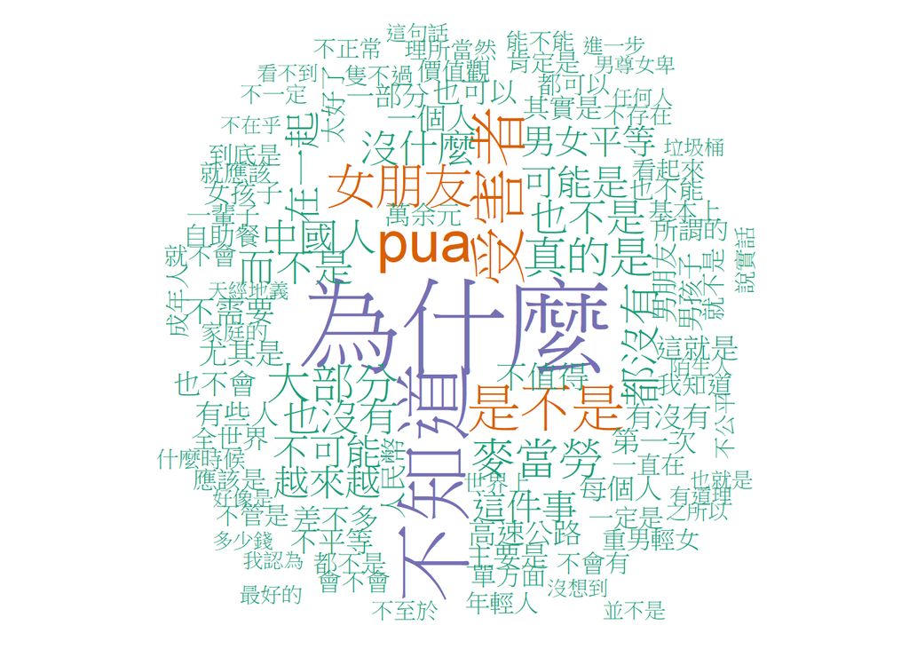

```
Word Cloud generated for: traditional_common_words_combined.csv
```

```r
source("Word_cloud_visualization.R")
```

```r
# Sort by frequency and assign ranks
zipf_data_ranked <- Traditional_Chinese_data_cleaned %>%
  arrange(desc(total_count)) %>%
  mutate(rank = row_number())

# Print the top 5 ranked words to confirm the data structure
print(head(zipf_data_ranked, 5))
```

```
  traditional_text total_count rank
1           為什麼         254    1
2           不知道         172    2
3           受害者         118    3
4              pua         116    4
5           是不是         101    5
```

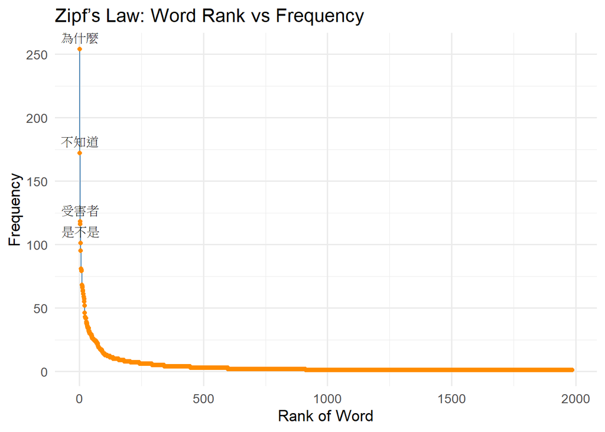

```r
# --- Linear Scale (As Requested) ---

ggplot(zipf_data_ranked, aes(x = rank, y = total_count)) +
  geom_line(color = "steelblue") +
  geom_point(color = "darkorange", size = 1.5) +
  geom_text(
    # Label the top 8 words
    aes(label = ifelse(rank <= 6, traditional_text, "")),
    vjust = -0.8,
    size = 3.5,
    check_overlap = TRUE # Prevents overlapping labels
  ) +
  labs(
    title = "Zipf’s Law: Word Rank vs Frequency",
    x = "Rank of Word",
    y = "Frequency"
  ) +
  theme_minimal(base_size = 13)
```

**Translation**

| **Rank** | **Word** | **Translate** |
| --- | --- | --- |
| 1 | 為什麼 | **“Why / Why is it that…”** |
| 2 | 不知道 | **“Don’t know”** |
| 3 | 受害者 | **“Victim”** |
| 4 | pua | **“PUA”** |
| 5 | 是不是 | **“Is it / Is it not?”** |
| 6 | 女朋友 | **“Girlfriend”** |

## Word Embedding

For semantic analysis, I applied Word2Vec using a pseudo-document approach to capture relationships between words in the comments. Each word was repeated according to its frequency (`total_count`) to create co-occurrence information, which is essential for small datasets where natural co-occurrences are limited. The repeated words were then combined into a single space-separated pseudo-document and used to train a skip-gram Word2Vec model with a vector dimension of 50, window size of 5, and 50 iterations, setting `min_count = 1` to include all words.

The resulting word vectors allow calculation of cosine similarity to examine semantic relationships between words, as well as clustering and downstream supervised learning tasks. For example, the vector for a keyword such as “為什麼” can be compared with all other word vectors to identify the top semantically similar words, revealing patterns in how concepts related to “SIMP” behavior are discussed in YouTube comments. This approach provides a robust representation of word meaning in the context of the dataset while accommodating the limited co-occurrence information inherent in smaller comment datasets.

```r
# Word2Vec can be the best option for the word embeding.

source("Word Embeddings.R")
```

[output not shown]

## Sentiment Analysis

For sentiment analysis, I applied a custom Chinese sentiment dictionary tailored to the context of “SIMP” behavior. The dictionary categorizes words into three groups: **positive** (supportive or relationship-related words such as “女朋友” and “關心”), **negative** (critical or unfairness-related words such as “不值得” and “不公平”), and **behavior** (attention-seeking or “simp” behavior words such as “pua” and “追求”). Using R, I computed sentiment scores for each word in the dataset by summing occurrences in these categories. A raw polarity score was calculated as the sum of positive and behavior counts minus negative counts, then normalized by the total occurrences of all dictionary words to produce a relative polarity measure.

```
[1] "DFM after Custom Simp Dictionary Lookup (Counts per category):"

### SUPERVISED LEARNING (Naive Bayes Classification)
[1] "Confusion Matrix:"

### LEXICON-BASED NTUSD SENTIMENT RESULTS
[1] "Mean Sentiment Score by Simping Label (NTUSD):"
# A tibble: 2 × 2
  contains_simp_factor mean_sentiment
  <fct>                         <dbl>
1 FALSE                       -0.0990
2 TRUE                        -0.477
```

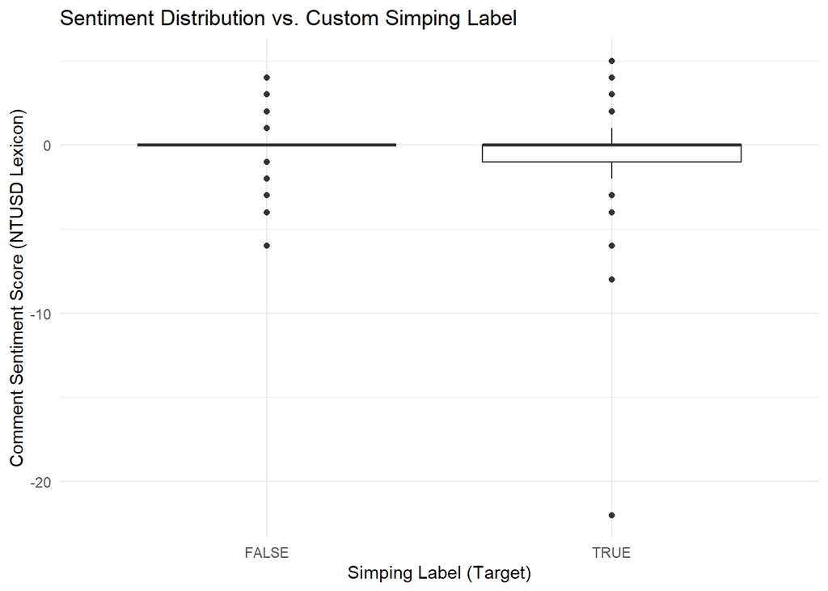

```r
source("Sentiment Analysis.R")
```

In this graph:

**X-Axis: Simping Label:**

- **FALSE:** Comments that **do not** contain any of the words from your custom “simp” dictionary (e.g., “舔狗,” “工具人,” “一廂情願,” etc.).
- **TRUE:** Comments that **do** contain at least one word from your custom “simp” dictionary.

**Y-Axis: Comment Sentiment Score**:

- **Positive Scores (above 0):** Indicate a more **positive** overall sentiment.
- **Zero (0):** Indicates a **neutral** or balanced sentiment.
- **Negative Scores (below 0):** Indicate a more **negative** overall sentiment.

## Supervised Learning Analysis (Naive Bayes Classification)

The Naive Bayes model was employed to classify comments based on whether they contained the “simp” factor, using a **cleaned feature set** that excluded all words from the custom “simp” dictionary to prevent data leakage. The model achieved an overall **Accuracy of 81.69%**, which is slightly higher than the No Information Rate (NIR) of 80.36%, indicating its performance is marginally better than random guessing based on class prevalence.

However, a closer look at the results reveals a significant **class imbalance issue** and skewed performance:

- **High Sensitivity (Recall):** The model is excellent at correctly identifying comments that **do NOT contain** the simp factor (the majority class, `FALSE`), with a high **Sensitivity of 95.72%**.
- **Low Specificity:** Conversely, the model is very poor at correctly identifying comments that **DO contain** the simp factor (the minority class, `TRUE`), with a low **Specificity of 24.29%**.
- **Kappa Value:** The **Kappa statistic of 0.2565** suggests only a **fair** level of agreement beyond chance.

In summary, the high overall accuracy is largely driven by correctly classifying the prevalent negative class (`FALSE`). The model struggles to reliably identify actual “simp” comments (`TRUE`), suggesting that the remaining general vocabulary in the comments **lacks sufficient predictive power** to consistently distinguish between the two categories without the core dictionary terms.

```r
source("Supervised_Learning.R")
```

```
--- Solving Data Leakage: Remove the word which exist in Simp dictionary ---
[1] "Original (matrix_main): 2703"
[1] "Remove the word in Simp dictionary (X_cleaned): 2674"

--- 6. Naive Bayes Training ---

--- Naive Bayes Prediction ---
[1] "Confusion Matrix:"
Confusion Matrix and Statistics

                 y_test
predicted_cleaned FALSE TRUE
            FALSE   693  134
            TRUE     31   43

               Accuracy : 0.8169
                 95% CI : (0.79, 0.8416)
    No Information Rate : 0.8036
    P-Value [Acc > NIR] : 0.1676

                  Kappa : 0.2565

 Mcnemar's Test P-Value : 2.011e-15

            Sensitivity : 0.9572
            Specificity : 0.2429
         Pos Pred Value : 0.8380
         Neg Pred Value : 0.5811
              Precision : 0.8380
                 Recall : 0.9572
                     F1 : 0.8936
             Prevalence : 0.8036
         Detection Rate : 0.7691
   Detection Prevalence : 0.9179
      Balanced Accuracy : 0.6001

       'Positive' Class : FALSE
```

## Topic Modeling (LDA)

The script follows a standard text mining workflow using the `tidyverse` and `text2vec` packages:

1. **Data Preparation:** It reads the individual tokenized comment files, reconstructs the full comments by assigning and aggregating tokens by a unique **document ID** (`doc_id`), and then combines the tokens back into complete text strings.
2. **Feature Engineering:** It creates an iterator from the aggregated text and builds a vocabulary. Crucially, it **prunes the vocabulary** by removing words that occur less than three times (`term_count_min = 3`), which helps reduce noise and improves the quality of the derived topics.
3. **DTM Creation:** The processed tokens are converted into a **Document-Term Matrix (DTM)**, which is the input required for LDA.
4. **Model Training:** The script initializes and trains an LDA model with a predefined number of topics (**K=8**) and **500 iterations**.
5. **Output:** Finally, the code extracts and saves two key results: the **Topic-Word distribution** (the top 10 most characteristic words for each of the 8 topics) and the **Document-Topic distribution** (the probability that each comment belongs to each topic), storing both as CSV files for subsequent qualitative analysis.

```r
source("Topic_Model.R")
```

```
[1] "Starting LDA Topic Modeling with K = 8"


[1] "LDA Training Complete."
```

```
[1] "Top 10 Words for Each Topic:"
# A tibble: 10 × 9
   Topic_Word_Rank Topic_0 Topic_1 Topic_2 Topic_3  Topic_4  Topic_5 Topic_6
   <chr>           <chr>   <chr>   <chr>   <chr>    <chr>    <chr>   <chr>
 1 Word_1          pua     不知道  受害者  是不是   為什麼   不知道  而不是
 2 Word_2          为什么  万余元  为什么  女朋友   在一起   越来越  這件事
 3 Word_3          中国人  pua     pua     为什么   也可以   大部分  不知道
 4 Word_4          男孩子  可能是  真的是  不知道   不可能   都不是  一定是
 5 Word_5          女孩子  一個人  麦当劳  不需要   都沒有   真的是  女朋友
 6 Word_6          也不是  這件事  家庭的  也没有   這就是   受害者  能不能
 7 Word_7          是不是  中国人  全世界  大部分   也沒有   女朋友  人民幣
 8 Word_8          没什么  尤其是  其实是  男朋友   男尊女卑 我知道  垃圾桶
 9 Word_9          可能是  真的是  好像是  男女平等 沒什麼   是不是  有些人
10 Word_10         不值得  為什麼  肯定是  所谓的   不存在   也不是  为什么
# ℹ 1 more variable: Topic_7 <chr>
[1] "Saved topic words to lda_topic_words.csv"
[1] "Document-Topic Distribution (Head):"
# A tibble: 6 × 9
  doc_id    V1    V2    V3    V4    V5    V6    V7    V8
   <int> <dbl> <dbl> <dbl> <dbl> <dbl> <dbl> <dbl> <dbl>
1      1     0  0      0    0      0     0       0     0
2      2     0  0      0    0      0     0       0     0
3      3     0  0.05   0    0.15   0.6   0.2     0     0
4      4     0  0.1    0.2  0      0.4   0.3     0     0
5      5     0  0      0.8  0      0.2   0       0     0
6      6     0  0      0    0      0     0       1     0
[1] "Saved document-topic distribution to lda_doc_topic_distr.csv"
```

**Translation for the every words in the topics**

| **Topic_Word_Rank** | **Topic_0** | **Topic_1** | **Topic_2** | **Topic_3** | **Topic_4** | **Topic_5** | **Topic_6** | **Topic_7** |
| --- | --- | --- | --- | --- | --- | --- | --- | --- |
| **Word_1** | **PUA** | Don’t know | **Victim** | Is it? | **Why** | Don’t know | And not | **Buffet** (Resource) |
| **Word_2** | Why | Over 10k yuan | Why | **Girlfriend** | **Be together** | More and more | This matter | Highway |
| **Word_3** | **Chinese people** | **PUA** | **PUA** | Why | Also can | **Majority** | Don’t know | Too good |
| **Word_4** | Boy / Male | Possibly | Truly is | Don’t know | Impossible | Are not all | Must be | Why |
| **Word_5** | Girl / Female | A person | **McDonald’s** | Don’t need | Don’t have at all | Truly is | **Girlfriend** | Mainly is |
| **Word_6** | Also is not | This matter | **Family’s** | Also don’t have | This is | **Victim** | Can or cannot | Some people |
| **Word_7** | Is it? | Chinese people | Whole world | **Majority** | Also don’t have | **Girlfriend** | **RMB** (Money) | **Inequality** |
| **Word_8** | Nothing much | Especially | Actually is | **Boyfriend** | **Male Superiority** | I know | **Trash Can** (Worthless) | Should be |
| **Word_9** | Possibly | Truly is | Seems like | **Gender Equality** | Nothing much | Is it? | Some people | A person |
| **Word_10** | **Not worth it** | Why | Definitely is | So-called | Does not exist | Also is not | Why | **Gender Equality** |

**The interpretation for each topic**

[output not shown]

| **DTM** | **Topic_Word_Rank** |
| --- | --- |
| V1 | Topic_0 |
| V2 | Topic_1 |
| V3 | Topic_2 |
| V4 | Topic_3 |
| V5 | Topic_4 |
| V6 | Topic_5 |
| V7 | Topic_6 |
| V8 | Topic_7 |

## Causal Inference

```
[1] "--- OLS Regression Results (Outcome: likeCount) ---"
[1] "Reference Topic: V8 (PUA/Victim)"

Call:
lm(formula = likeCount ~ V1 + V2 + V3 + V4 + V5 + V6 + V7, data = merged_df)

Residuals:
    Min      1Q  Median      3Q     Max
 -18.59   -8.93   -6.76   -5.12 1763.41

Coefficients:
            Estimate Std. Error t value Pr(>|t|)
(Intercept)    8.934      2.301   3.882 0.000106 ***
V1            -2.424      4.144  -0.585 0.558600
V2             9.655      4.656   2.074 0.038172 *
V3            -2.701      4.312  -0.626 0.531107
V4            -2.380      4.266  -0.558 0.576978
V5            -2.815      4.399  -0.640 0.522298
V6             1.729      4.351   0.398 0.691027
V7            -0.953      4.363  -0.218 0.827099
---
Signif. codes:  0 '***' 0.001 '**' 0.01 '*' 0.05 '.' 0.1 ' ' 1

Residual standard error: 56.08 on 2998 degrees of freedom
Multiple R-squared:  0.002579,  Adjusted R-squared:  0.00025
F-statistic: 1.107 on 7 and 2998 DF,  p-value: 0.3553
```

[figure not shown]

```r
source("Causal_Inference.R")
```

## Future

Future work should prioritize addressing the observed limitations in both the supervised classification model and the initial data preprocessing pipeline to enhance the robustness and explanatory power of the analysis. **Firstly**, while the initial Naive Bayes classifier provided baseline insights, its predictive performance should be critically re-evaluated. Improving the accuracy of the automated *simp* classification label requires exploring more sophisticated machine learning techniques, such as **Support Vector Machines (SVMs)**, **Gradient Boosting**, or even **Transformer-based deep learning models**. Concurrently, enhancing the feature set by refining or expanding the custom dictionaries—perhaps incorporating sentiment scores or incorporating **word embeddings**—could significantly boost the model’s ability to discriminate between classes, moving beyond simple bag-of-words approaches. **Secondly**, a crucial area for improvement lies in the **token filtering and data processing stage**. Despite standard removal procedures, the presence of numerous contextually irrelevant tokens, such as specific objects (“高速公路”) and brands (“麥當勞”), confirms the necessity of a more rigorous, domain-specific cleanup. Future efforts must focus on constructing an expanded, **domain-aware stop word list** or implementing **Named Entity Recognition (NER)** to systematically identify and remove non-topical, low-information tokens, ensuring the remaining features are highly predictive and representative of the core concepts being discussed.

## Reference

HO, Daniel. The (simp)le truth about excessive & obsessive romantic behaviors in men. (2023). https://ink.library.smu.edu.sg/etd_coll/516

Krishnamurthy, V., & Duan, Y. (2017). Dependence Structure Analysis Of Meta-level Metrics in YouTube Videos: A Vine Copula Approach. arXiv preprint arXiv:1712.10232. “to explain the comment and the view of the video are related”

Lun-Wei Ku and Hsin-Hsi Chen (2007). Mining Opinions from the Web: Beyond Relevance Retrieval. Journal of American Society for Information Science and Technology, Special Issue on Mining Web Resources for Enhancing Information Retrieval, 58(12), pages 1838-1850.

Pew Research Center. (2020). Many Americans get news on YouTube, where news organizations and independent producers thrive side by side. https://www.pewresearch.org/journalism/2020/09/28/many-americans-get-news-on-youtube-where-news-organizations-and-independent-producers-thrive-side-by-side/

Zhou, W. (2024). 重庆警方发布“胖猫”事件警情通报 [Chongqing police issue incident report on the “Pangmao” incident]. Xinhua Net. http://www.news.cn/politics/20240519/fb56352660c94810a58e79bc18459a3e/c.html